# Cat*Con Interactions

Tom Booth

2022-11-01

This document is to briefly elaborate the difference between two linear models with a continous outcome ( $y$ ), a continuous predictor ( $x$ ) and a binary predictor ( $z$ ) First with no interaction. :

$$y = b_0 + b_1x + b_2z +
\epsilon$$

And second with an interaction:

$$y = b_0 + b_1x + b_2z + b_3xz +
\epsilon$$

```r
m1 <- lm(score ~ hours + study, data = data1)
summary(m1)
```

```
##
## Call:
## lm(formula = score ~ hours + study, data = data1)
##
## Residuals:
##     Min      1Q  Median      3Q     Max
## -14.727  -3.027  -0.196   3.500  15.988
##
## Coefficients:
##             Estimate Std. Error t value Pr(>|t|)
## (Intercept) 12.17651    0.74153  16.421  < 2e-16 ***
## hours        1.27543    0.07185  17.751  < 2e-16 ***
## studyothers  5.63215    0.67232   8.377 4.11e-15 ***
## ---
## Signif. codes:  0 '***' 0.001 '**' 0.01 '*' 0.05 '.' 0.1 ' ' 1
##
## Residual standard error: 5.245 on 247 degrees of freedom
## Multiple R-squared:  0.5964, Adjusted R-squared:  0.5931
## F-statistic: 182.5 on 2 and 247 DF,  p-value: < 2.2e-16
```

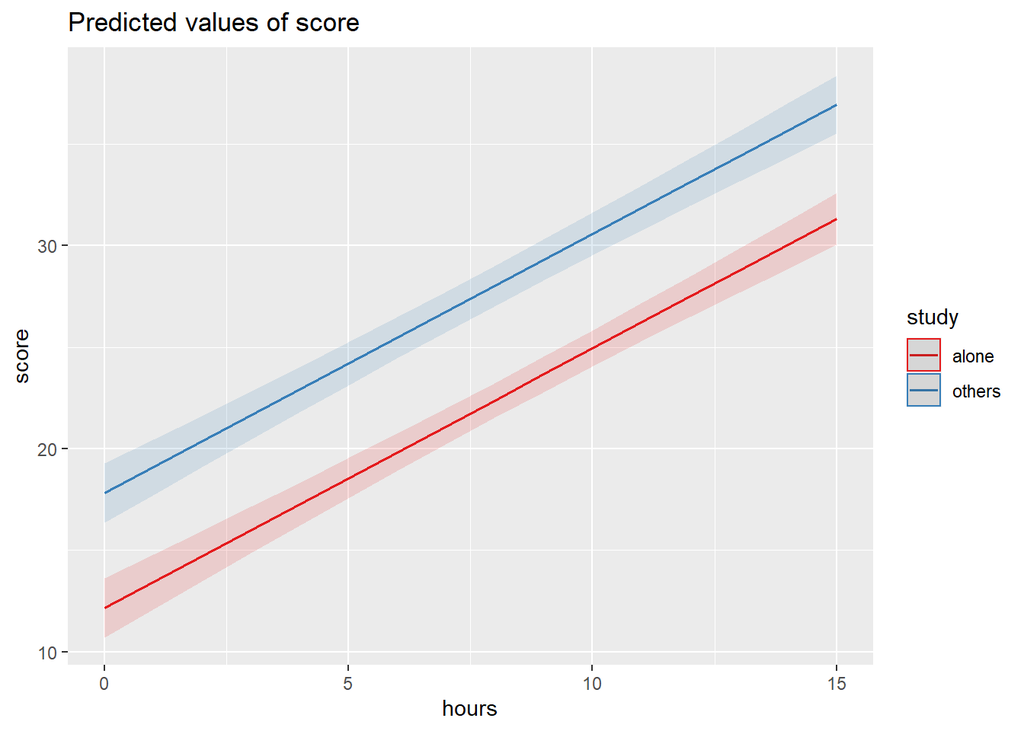

```r
sjPlot::plot_model(m1, type="pred", terms=c("hours","study"))
```

- $b_0$ = 12.177 the point where the red line crosses 0. For someone who studies no hours in the `alone` group, expected test score is 12.18
- $b_1$ = 1.275 the slope of both lines. For each additional hour of study, score increases by 1.28 points
- $b_2$ = 5.632 the point where the blue line crosses 0. The difference in the intercepts between study `alone` and with `others`. Those who study with others and have 0 hours of revision have an expected test score of 17.809 (5.632 higher than $b_0$ )

```r
m2 <- lm(score ~ hours + study + hours*study, data = data2)
summary(m2)
```

```
##
## Call:
## lm(formula = score ~ hours + study + hours * study, data = data2)
##
## Residuals:
##      Min       1Q   Median       3Q      Max
## -14.9781  -3.1255  -0.1569   3.3343  15.9687
##
## Coefficients:
##                   Estimate Std. Error t value Pr(>|t|)
## (Intercept)       12.50657    0.91363  13.689  < 2e-16 ***
## hours              1.23576    0.09627  12.836  < 2e-16 ***
## studyothers        4.92013    1.33127   3.696  0.00027 ***
## hours:studyothers  2.08981    0.14487  14.425  < 2e-16 ***
## ---
## Signif. codes:  0 '***' 0.001 '**' 0.01 '*' 0.05 '.' 0.1 ' ' 1
##
## Residual standard error: 5.251 on 246 degrees of freedom
## Multiple R-squared:  0.8901, Adjusted R-squared:  0.8888
## F-statistic: 664.5 on 3 and 246 DF,  p-value: < 2.2e-16
```

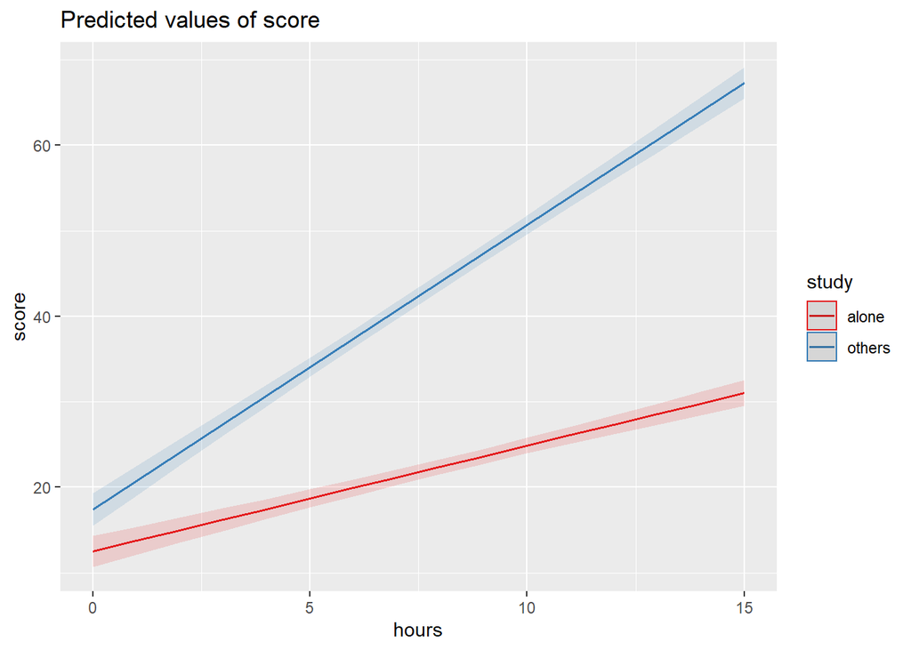

```r
sjPlot::plot_model(m2, type="int")
```

- $b_0$ = 12.507 the point where the red line crosses 0. For someone who studies no hours in the `alone` group, expected test score is 12.51
- $b_1$ = 1.236 the slope for those who study `alone`. For each additional hour of study, score increases by 1.24 points
- $b_2$ = 4.92 the point where the blue line crosses 0. The difference in the intercepts between study `alone` and with `others`. Those who study with others and have 0 hours of revision have an expected test score of 17.427 (4.92 higher than $b_0$ )
- $b_3$ = 2.09 the difference in slopes between red and blue lines. The difference in effect of hours between study `alone` and with `others`. Those who study with others have a more positive effect of hours studied (more effective) than those who study alone. The slope for others is 3.326 ( $b_1 + b_3$ )